# Mendelian Randomization Analysis

Dr. Shea Andrews

2018-10-12

## Instrumental Variables

**SNP Inclusion:** SNPS associated with at a p-value threshold of p < 5e-6 were included in this analysis.

**LD Clumping:** For standard two sample MR it is important to ensure that the instruments for the exposure are independent. LD clumping was performed in PLINK using the EUR samples from the 1000 Genomes Project to estimate LD between SNPs, and, amongst SNPs that have an LD above a given threshold, retain only the SNP with the lowest p-value. A clumping window of 250kb, r2 of 0.1 and significance level of 1 was used for the index and secondary SNPs.

**Proxy SNPs:** Where SNPs were not available in the outcome GWAS, the EUR thousand genomes was queried to identify potential proxy SNPs that are in linkage disequilibrium (r2 > 0.8) of the missing SNP.

### Exposure: LOAD

*Late Onset Alzheimer’s disease* [Lambert et al 2013](https://doi.org/10.1038/ng.2802): The International Genomics of Alzheimers Project (IGAP) is a meta-analysis of 4 previously published GWAS datasets: the European Alzheimers Disease Imitative (EADI), the Alzheimer Disease Genetics Consortium (ADGC), Cohorts for Heart and Aging Research in Genomic Epidemiology (CHARGE), and Genetic and Environmental Risk in AD (GERAD) and includes a sample of 17,008 LOAD cases and 37,154 cognitively normal elder controls. Participants in IGAP were of European ancestry, the average age was 71 and 58.4% of participants were women.

**Table 1:** Independent SNPs associated with LOAD

| SNP | CHR | POS | Effect_allele | Non_Effect_allele | EAF | Beta | SE | P | r2 | N |
| --- | --- | --- | --- | --- | --- | --- | --- | --- | --- | --- |
| rs1410397 | 1 | 193627682 | C | T | 0.5348 | 0.0766 | 0.0160 | 1.616e-06 | 0.002919568 | 54162 |
| rs1752684 | 1 | 207747296 | A | G | 0.1987 | 0.1541 | 0.0196 | 3.653e-15 | 0.007561854 | 54162 |
| rs4147104 | 1 | 207882194 | A | G | NA | 0.0774 | 0.0167 | 3.421e-06 | NA | 54162 |
| rs4663105 | 2 | 127891427 | C | A | 0.5664 | 0.1837 | 0.0172 | 1.001e-26 | 0.016575278 | 54162 |
| rs745717 | 2 | 127893897 | C | G | 0.0992 | 0.2008 | 0.0288 | 2.879e-12 | 0.007206053 | 54162 |
| rs62273237 | 3 | 128310107 | T | C | 0.4035 | 0.0748 | 0.0160 | 2.768e-06 | 0.002693315 | 54162 |
| rs7657553 | 4 | 11723235 | A | G | 0.2797 | 0.0830 | 0.0172 | 1.462e-06 | 0.002775825 | 54162 |
| rs190982 | 5 | 88223420 | G | A | 0.6141 | -0.0799 | 0.0170 | 2.547e-06 | 0.003025781 | 54162 |
| rs2878896 | 5 | 139710507 | G | A | 0.5077 | 0.0833 | 0.0156 | 9.219e-08 | 0.003468622 | 54162 |
| rs28895055 | 6 | 32417185 | G | A | 0.8762 | 0.1193 | 0.0253 | 2.299e-06 | 0.003087698 | 54162 |

[output cut: 79 more lines]

### Outcome: Systolic Blood Pressure

*Systolic Blood Pressure* [Evangelou et al 2018, Nature Genetics](https://doi.org/10.1038/s41588-018-0205-x): We report the largest genetic association study of blood pressure traits (systolic, diastolic and pulse pressure) to date in over 1 million people of European ancestry. We identify 535 novel blood pressure loci that not only offer new biological insights into blood pressure regulation but also highlight shared genetic architecture between blood pressure and lifestyle exposures.

**Table 2:** SNPs associated with LOAD avaliable in Systolic Blood Pressure

| SNP | CHR | POS | Effect_allele | Non_Effect_allele | EAF | Beta | SE | P | r2 | N |
| --- | --- | --- | --- | --- | --- | --- | --- | --- | --- | --- |
| rs1410397 | 1 | 193627682 | T | C | 0.5388 | 0.0343 | 0.0303 | 2.584e-01 | 5.847027e-04 | 729908 |
| rs1752684 | 1 | 207747296 | A | G | 0.1870 | 0.0171 | 0.0387 | 6.576e-01 | 8.891077e-05 | 738167 |
| rs4147104 | NA | NA | NA | NA | NA | NA | NA | NA | NA | NA |
| rs4663105 | 2 | 127891427 | A | C | 0.5794 | -0.0586 | 0.0313 | 6.069e-02 | 1.673682e-03 | 737165 |
| rs745717 | 2 | 127893897 | C | G | 0.0904 | -0.1025 | 0.0546 | 6.067e-02 | 1.727812e-03 | 737164 |
| rs62273237 | 3 | 128310107 | T | C | 0.4036 | 0.0168 | 0.0308 | 5.862e-01 | 1.358743e-04 | 737056 |
| rs7657553 | 4 | 11723235 | A | G | 0.2781 | 0.0033 | 0.0337 | 9.223e-01 | 4.372561e-06 | 738170 |
| rs190982 | 5 | 88223420 | A | G | 0.6076 | 0.0515 | 0.0317 | 1.041e-01 | 1.264711e-03 | 737164 |
| rs2878896 | 5 | 139710507 | A | G | 0.5141 | -0.0874 | 0.0303 | 3.950e-03 | 3.816343e-03 | 738170 |
| rs28895055 | NA | NA | NA | NA | NA | NA | NA | NA | NA | NA |

[output cut: 79 more lines]

**Table 3:** Proxy SNPs for Systolic Blood Pressure

| query_snp_rsid | rsID | ld.r2 | Dprime | ref.proxy | alt.proxy | CHR | POS | Effect_allele.proxy | Non_Effect_allele.proxy | EAF | Beta | SE | P | r2 | N | ref | alt | Effect_allele | Non_Effect_allele |
| --- | --- | --- | --- | --- | --- | --- | --- | --- | --- | --- | --- | --- | --- | --- | --- | --- | --- | --- | --- |
| rs111679419 | NA | NA | NA | NA | NA | NA | NA | NA | NA | NA | NA | NA | NA | NA | NA | NA | NA | NA | NA |
| rs116949436 | NA | NA | NA | NA | NA | NA | NA | NA | NA | NA | NA | NA | NA | NA | NA | NA | NA | NA | NA |
| rs138607350 | NA | NA | NA | NA | NA | NA | NA | NA | NA | NA | NA | NA | NA | NA | NA | NA | NA | NA | NA |
| rs149720917 | rs143560707 | 0.93 | 1 | C | G | 15 | 64745259 | C | G | 0.9778 | 0.0535 | 0.1102 | 0.6274 | 0.0001242626 | 739581 | C | G | C | G |
| rs28366259 | NA | NA | NA | NA | NA | NA | NA | NA | NA | NA | NA | NA | NA | NA | NA | NA | NA | NA | NA |
| rs28895055 | rs13199014 | 0.87 | 1 | A | C | 6 | 32419012 | A | C | 0.8429 | -0.0626 | 0.0443 | 0.1576 | 0.0010378412 | 661844 | A | G | A | G |
| rs34583389 | NA | NA | NA | NA | NA | NA | NA | NA | NA | NA | NA | NA | NA | NA | NA | NA | NA | NA | NA |
| rs41269974 | NA | NA | NA | NA | NA | NA | NA | NA | NA | NA | NA | NA | NA | NA | NA | NA | NA | NA | NA |
| rs41290100 | NA | NA | NA | NA | NA | NA | NA | NA | NA | NA | NA | NA | NA | NA | NA | NA | NA | NA | NA |
| rs4147104 | NA | NA | NA | NA | NA | NA | NA | NA | NA | NA | NA | NA | NA | NA | NA | NA | NA | NA | NA |

[output cut: 1 more lines]

## Data harmonization

Harmonize the exposure and outcome datasets so that the effect of a SNP on the exposure and the effect of that SNP on the outcome correspond to the same allele. The harmonise_data function from the TwoSampleMR package can be used to perform the harmonization step, by default it try’s to infer the forward strand alleles using allele frequency information. EAF were not availbe in the IGAP summary statisitics, as such the allele frequencies reported in the AAOS anaylsis were used.

**Table 4:** Harmonized LOAD and Systolic Blood Pressure datasets

| SNP | effect_allele.exposure | other_allele.exposure | effect_allele.outcome | other_allele.outcome | beta.exposure | beta.outcome | eaf.exposure | eaf.outcome | remove | palindromic | ambiguous | id.outcome | se.outcome | pval.outcome | outcome | mr_keep.outcome | pval_origin.outcome | se.exposure | pval.exposure | exposure | mr_keep.exposure | pval_origin.exposure | id.exposure | action | mr_keep | samplesize.outcome | mrpresso_RSSobs | mrpresso_pval | mrpresso_keep |
| --- | --- | --- | --- | --- | --- | --- | --- | --- | --- | --- | --- | --- | --- | --- | --- | --- | --- | --- | --- | --- | --- | --- | --- | --- | --- | --- | --- | --- | --- |
| rs10143128 | C | T | C | T | 0.2091 | 0.0542 | 0.9437 | 0.0681 | FALSE | FALSE | FALSE | VHK2Hm | 0.0609 | 3.738e-01 | sbp | TRUE | reported | 0.0393 | 1.004e-07 | load | TRUE | reported | hMkM89 | 2 | TRUE | NA | 1.003383e-03 | 1 | TRUE |
| rs10401176 | T | C | T | C | -0.2139 | -0.2227 | 0.1204 | 0.1247 | FALSE | FALSE | FALSE | VHK2Hm | 0.0486 | 4.510e-06 | sbp | TRUE | reported | 0.0317 | 1.508e-11 | load | TRUE | reported | hMkM89 | 2 | TRUE | NA | 4.046196e-02 | <0.0079 | FALSE |
| rs10415949 | G | A | G | A | -0.0901 | -0.0982 | 0.7613 | 0.2407 | FALSE | FALSE | FALSE | VHK2Hm | 0.0357 | 6.004e-03 | sbp | TRUE | reported | 0.0184 | 1.024e-06 | load | TRUE | reported | hMkM89 | 2 | TRUE | NA | 7.861683e-03 | 1 | TRUE |
| rs10426759 | A | G | A | G | 0.0787 | 0.0220 | 0.5239 | 0.5240 | FALSE | FALSE | FALSE | VHK2Hm | 0.0304 | 4.691e-01 | sbp | TRUE | reported | 0.0168 | 2.844e-06 | load | TRUE | reported | hMkM89 | 2 | TRUE | NA | 1.822866e-04 | 1 | TRUE |
| rs10509088 | T | C | T | C | -0.1813 | 0.0369 | 0.0444 | 0.0444 | FALSE | FALSE | FALSE | VHK2Hm | 0.0738 | 6.169e-01 | sbp | TRUE | reported | 0.0387 | 2.786e-06 | load | TRUE | reported | hMkM89 | 2 | TRUE | NA | 3.216257e-03 | 1 | TRUE |
| rs10792832 | A | G | A | G | -0.1297 | 0.0371 | 0.3563 | 0.3691 | FALSE | FALSE | FALSE | VHK2Hm | 0.0311 | 2.329e-01 | sbp | TRUE | reported | 0.0161 | 6.534e-16 | load | TRUE | reported | hMkM89 | 2 | TRUE | NA | 2.657410e-03 | 1 | TRUE |
| rs10808026 | A | C | A | C | -0.1393 | 0.0221 | 0.1883 | 0.2097 | FALSE | FALSE | FALSE | VHK2Hm | 0.0377 | 5.580e-01 | sbp | TRUE | reported | 0.0206 | 1.417e-11 | load | TRUE | reported | hMkM89 | 2 | TRUE | NA | 1.400833e-03 | 1 | TRUE |
| rs111278892 | G | C | G | C | 0.1867 | 0.1303 | 0.8544 | 0.8489 | FALSE | TRUE | FALSE | VHK2Hm | 0.0447 | 3.543e-03 | sbp | TRUE | reported | 0.0371 | 4.813e-07 | load | TRUE | reported | hMkM89 | 2 | TRUE | NA | 1.229190e-02 | 0.948 | TRUE |
| rs11218343 | C | T | C | T | -0.2697 | 0.0024 | 0.9605 | 0.0387 | FALSE | FALSE | FALSE | VHK2Hm | 0.0788 | 9.757e-01 | sbp | TRUE | reported | 0.0410 | 4.976e-11 | load | TRUE | reported | hMkM89 | 2 | TRUE | NA | 1.012147e-03 | 1 | TRUE |
| rs11257242 | C | G | C | G | -0.0809 | -0.0369 | 0.3429 | 0.3483 | FALSE | TRUE | FALSE | VHK2Hm | 0.0320 | 2.485e-01 | sbp | TRUE | reported | 0.0170 | 1.952e-06 | load | TRUE | reported | hMkM89 | 2 | TRUE | NA | 7.952865e-04 | 1 | TRUE |

[output cut: 69 more lines]

## MR Results

To obtain an overall estimate of causal effect, the SNP-exposure and SNP-outcome coefficients were combined in 1) a fixed-effects meta-analysis using an inverse-variance weighted approach (IVW); 2) a Weighted Median approach; 3) Weighted Mode approach and 4) Egger Regression.

[**IVW**](https://doi.org/10.1002/gepi.21758) is equivalent to a weighted regression of the SNP-outcome coefficients on the SNP-exposure coefficients with the intercept constrained to zero. This method assumes that all variants are valid instrumental variables based on the Mendelian randomization assumptions. The causal estimate of the IVW analysis expresses the causal increase in the outcome (or log odds of the outcome for a binary outcome) per unit change in the exposure. [**Weighted median MR**](https://doi.org/10.1002/gepi.21965) allows for 50% of the instrumental variables to be invalid. [**MR-Egger regression**](https://doi.org/10.1093/ije/dyw220) allows all the instrumental variables to be subject to direct effects (i.e. horizontal pleiotropy), with the intercept representing bias in the causal estimate due to pleiotropy and the slope representing the causal estimate. [**Weighted Mode**](https://doi.org/10.1093/ije/dyx102) gives consistent estimates as the sample size increases if a plurality (or weighted plurality) of the genetic variants are valid instruments.

Table 5 presents the MR causal estimates of genetically predicted LOAD on Systolic Blood Pressure.

**Table 5** MR causaul estimates for LOAD on Systolic Blood Pressure

| id.exposure | id.outcome | outcome | exposure | method | nsnp | b | se | pval |
| --- | --- | --- | --- | --- | --- | --- | --- | --- |
| hMkM89 | VHK2Hm | sbp | load | Inverse variance weighted (fixed effects) | 78 | 0.108532740 | 0.02063569 | 1.444729e-07 |
| hMkM89 | VHK2Hm | sbp | load | Weighted median | 78 | 0.040100283 | 0.04780314 | 4.015462e-01 |
| hMkM89 | VHK2Hm | sbp | load | Weighted mode | 78 | -0.027551261 | 0.03519307 | 4.361102e-01 |
| hMkM89 | VHK2Hm | sbp | load | MR Egger | 78 | 0.005015496 | 0.06777248 | 9.412009e-01 |

Figure 1 illustrates the SNP-specific associations with LOAD versus the association in Systolic Blood Pressure and the corresponding MR estimates.

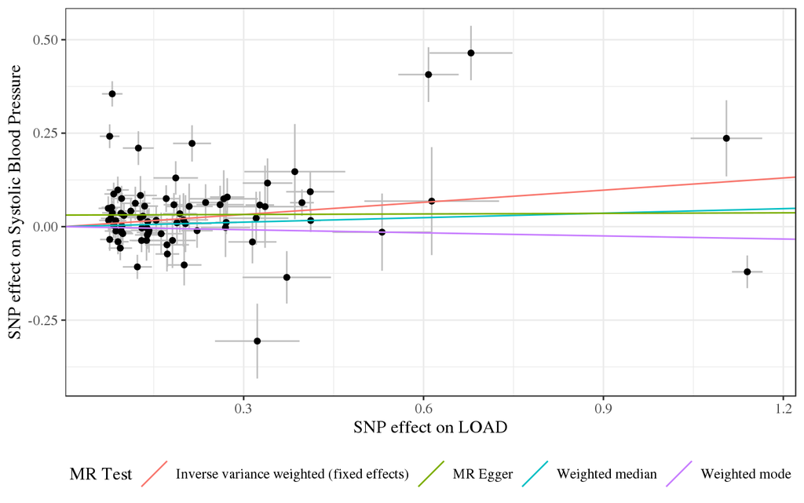

Fig. 1: Scatterplot of SNP effects for the association of the Exposure on the Outcome

## Pleiotropy

Figure 2 shows a funnel plot displaying the MR estimates of individual genetic variants against their precession. Aysmmetry in the funnel plot may arrise due to some genetic variants having unusally strong effects on the outcome, which is indicative of directional pleiotropy.

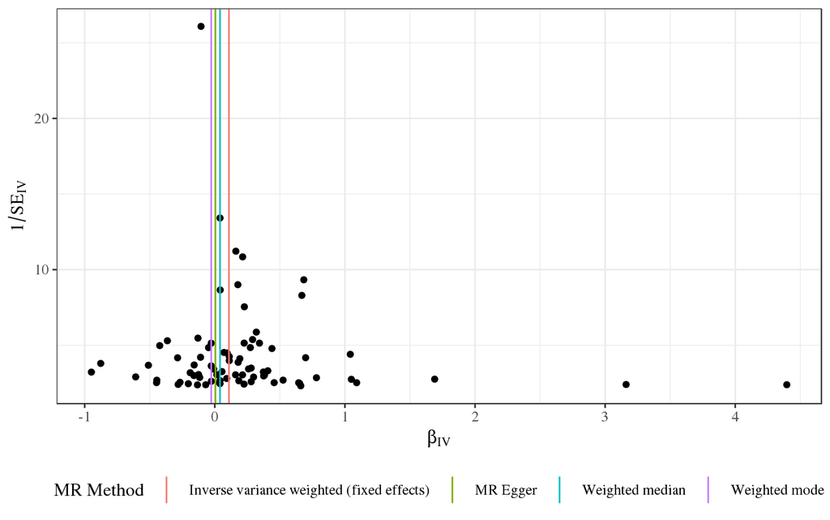

Fig. 2: Funnel plot of the MR causal estimates against their precession

A Cochrans Q heterogeneity test can be used to formaly assesse for the presence of heterogenity (Table 6).

**Table 6:** Heterogenity Tests

| id.exposure | id.outcome | outcome | exposure | method | Q | Q_df | Q_pval |
| --- | --- | --- | --- | --- | --- | --- | --- |
| hMkM89 | VHK2Hm | sbp | load | MR Egger | 368.0474 | 76 | 6.884535e-40 |
| hMkM89 | VHK2Hm | sbp | load | Inverse variance weighted | 388.5513 | 77 | 4.056358e-43 |

The intercept of the MR-Regression model captures the average pleitropic affect across all genetic variants (Table 7).

**Table 7:** MR Egger test for directional pleitropy

| id.exposure | id.outcome | outcome | exposure | egger_intercept | se | pval |
| --- | --- | --- | --- | --- | --- | --- |
| hMkM89 | VHK2Hm | sbp | load | 0.03098582 | 0.01505878 | 0.04305271 |

Pleiotropy was also assesed using Mendelian Randomization Pleiotropy RESidual Sum and Outlier [(MR-PRESSO)](https://doi.org/10.1038/s41588-018-0099-7), that allows for the evlation of evaluation of horizontal pleiotropy in a standared MR model (Table 8). MR-PRESSO performs a global test for detection of horizontal pleiotropy and correction of pleiotropy via outlier removal (Table 9).

**Table 8:** MR-PRESSO Global Test for pleitropy

| id.exposure | id.outcome | outcome | exposure | n_outliers | RSSobs | pval |
| --- | --- | --- | --- | --- | --- | --- |
| hMkM89 | VHK2Hm | sbp | load | 8 | 425.6378 | <1e-04 |

**Table 9:** MR Estimates after MR-PRESSO outlier removal

| id.exposure | id.outcome | outcome | exposure | method | nsnp | b | se | pval |
| --- | --- | --- | --- | --- | --- | --- | --- | --- |
| hMkM89 | VHK2Hm | sbp | load | Inverse variance weighted (fixed effects) | 70 | 0.10802612 | 0.02617872 | 3.683498e-05 |
| hMkM89 | VHK2Hm | sbp | load | Weighted median | 70 | 0.15989313 | 0.04184225 | 1.327329e-04 |
| hMkM89 | VHK2Hm | sbp | load | Weighted mode | 70 | 0.14296283 | 0.04764360 | 3.746736e-03 |
| hMkM89 | VHK2Hm | sbp | load | MR Egger | 70 | 0.08861243 | 0.05669302 | 1.226897e-01 |

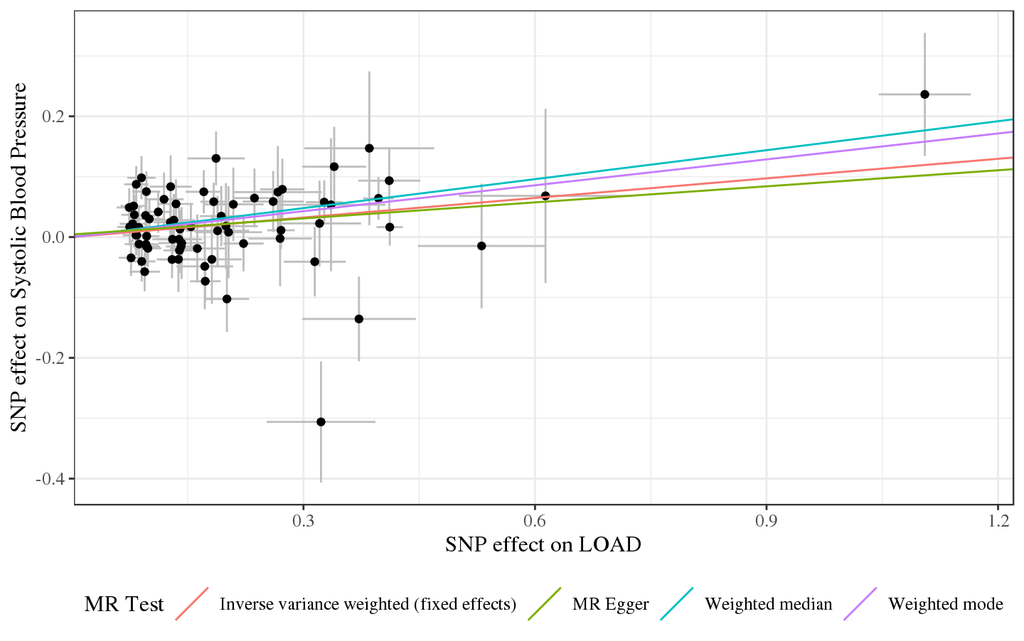

Fig. 3: Scatterplot of SNP effects for the association of the Exposure on the Outcome after outlier removal